# Imputation comparison test

TEST 1

05-03-25

## Data

Your data has 100 rows (samples) and 101 columns (features) - if the first column is not numeric then its probably an ID column and we have converted it to rownames so the number of features will be 100. This is what your data looks like:

raw data

|  | feature_1 | feature_2 | feature_3 | feature_4 | feature_5 | feature_6 | feature_7 | feature_8 | feature_9 | feature_10 | feature_11 | feature_12 | feature_13 | feature_14 | feature_15 | feature_16 | feature_17 | feature_18 | feature_19 | feature_20 | feature_21 | feature_22 | feature_23 | feature_24 | feature_25 | feature_26 | feature_27 | feature_28 | feature_29 | … |
| --- | --- | --- | --- | --- | --- | --- | --- | --- | --- | --- | --- | --- | --- | --- | --- | --- | --- | --- | --- | --- | --- | --- | --- | --- | --- | --- | --- | --- | --- | --- |
| ID_1 | 0.6810971 | 0.8138630 | 0.6285466 | 0.7279544 | 0.1803924 | 0.4242241 | 0.8346470 | 0.3253558 | 0.8410309 | 0.7142484 | 0.6104310 | 0.5765397 | 0.7172757 | 0.0567127 | 0.6286282 | 0.5773724 | 0.6425210 | 0.1502184 | 0.9849136 | 0.0966758 | 0.0347764 | 0.9733170 | 0.0225877 | 0.4069631 | 0.1065538 | 0.5206529 | 0.6506825 | 0.1123078 | 0.9784639 | … |
| ID_2 | 0.7751585 | 0.0528117 | 0.8409242 | 0.5337836 | 0.9415547 | 0.8152283 | 0.3563849 | 0.0096131 | 0.2188087 | 0.9129935 | 0.2250014 | 0.0041217 | 0.7781523 | 0.3667516 | 0.0229583 | 0.1505677 | 0.0690735 | 0.9269476 | 0.0941919 | 0.2238621 | 0.2071239 | 0.6590757 | 0.3442074 | 0.6751206 | 0.0481757 | 0.4493308 | 0.9482651 | 0.0243024 | 0.5214366 | … |
| ID_3 | 0.7129480 | 0.5507582 | 0.5915310 | 0.1610310 | 0.7821776 | 0.4812830 | 0.9241851 | 0.7597444 | 0.2205220 | 0.2855512 | 0.2329278 | 0.3321172 | 0.9404875 | 0.4505441 | 0.9259084 | 0.1832808 | 0.7283838 | 0.9785809 | 0.5101072 | 0.9922727 | 0.3314844 | 0.5626118 | 0.7629309 | 0.2934993 | 0.8202375 | 0.3401139 | 0.9024629 | 0.4674471 | 0.6650369 | … |
| ID_4 | 0.9627908 | 0.6624494 | 0.2318512 | 0.7096050 | 0.2610674 | 0.4978892 | 0.8004726 | 0.5180744 | 0.1629293 | 0.3554675 | 0.8118151 | 0.8957274 | 0.3294676 | 0.7851845 | 0.9031028 | 0.7909790 | 0.0921200 | 0.8079033 | 0.6697780 | 0.4743560 | 0.3322596 | 0.0366951 | 0.5022371 | 0.3022832 | 0.4479140 | 0.1515303 | 0.2906374 | 0.0290562 | 0.9255035 | … |
| ID_5 | 0.6975291 | 0.7629973 | 0.9791543 | 0.8578014 | 0.1200541 | 0.9183115 | 0.4812407 | 0.3071563 | 0.8598928 | 0.3754986 | 0.7359673 | 0.8344614 | 0.7370239 | 0.5335947 | 0.3562299 | 0.4685684 | 0.7884392 | 0.1812977 | 0.0282327 | 0.2019809 | 0.5507141 | 0.7305257 | 0.7393181 | 0.4341892 | 0.3220190 | 0.4340360 | 0.9095902 | 0.4969628 | 0.4874125 | … |
| ID_6 | 0.6918353 | 0.8519245 | 0.5237761 | 0.3471170 | 0.5956315 | 0.6762585 | 0.1995913 | 0.9611980 | 0.4467162 | 0.5215275 | 0.6414683 | 0.8349737 | 0.2470002 | 0.5082424 | 0.0816782 | 0.9148469 | 0.1632759 | 0.9946453 | 0.8409862 | 0.1906923 | 0.2344206 | 0.3254216 | 0.3518123 | 0.9758056 | 0.5736769 | 0.8979820 | 0.8948019 | 0.2479820 | 0.7575646 | … |

The below table gives the `summary()` of missingness across your data. The bar charts show feature (top) and sample (bottom) missingness and the scatter plot shows the median of each feature plotted against the detection frequency (calculated as $1 - \text{total NA}$) for each feature.

summary of missingness

|  | Min. | 1st Qu. | Median | Mean | 3rd Qu. | Max. |
| --- | --- | --- | --- | --- | --- | --- |
| Value | 0 | 0 | 0 | 1.23 | 2 | 6 |

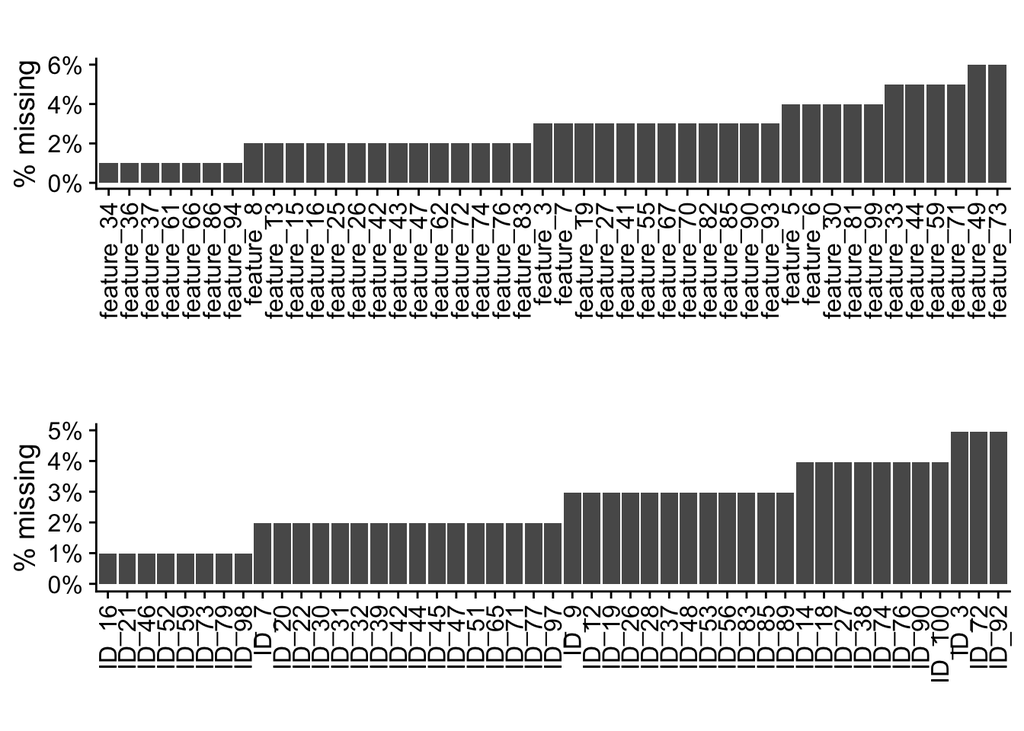

missingness for features and samples - only features and samples with missingness shown

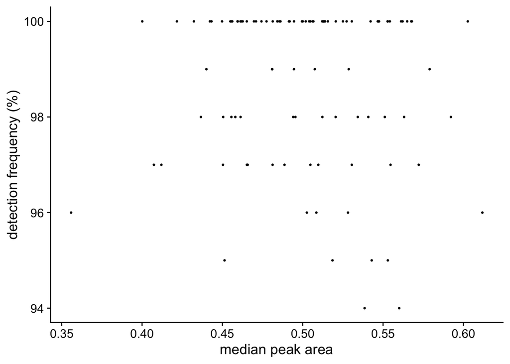

median raw intensity plotted against detection frequency